# Risk Factor Analysis

## Outcome Variable

**Outcome Variable:** stunted

## Predictor Variables

**Intervention Variable:** mwtkg

**Adjustment Set:**

unadjusted

## Stratifying Variables

The analysis was stratified on these variable(s):

- agecat
- studyid
- country

## Data Summary

| agecat | studyid | country | mwtkg | stunted | n_cell | n |
| --- | --- | --- | --- | --- | --- | --- |
| Birth | ki0047075b-MAL-ED | BANGLADESH | >=58 kg | 0 | 40 | 246 |
| Birth | ki0047075b-MAL-ED | BANGLADESH | >=58 kg | 1 | 7 | 246 |
| Birth | ki0047075b-MAL-ED | BANGLADESH | <52 kg | 0 | 126 | 246 |
| Birth | ki0047075b-MAL-ED | BANGLADESH | <52 kg | 1 | 30 | 246 |
| Birth | ki0047075b-MAL-ED | BANGLADESH | [52-58) kg | 0 | 38 | 246 |
| Birth | ki0047075b-MAL-ED | BANGLADESH | [52-58) kg | 1 | 5 | 246 |
| Birth | ki0047075b-MAL-ED | BRAZIL | >=58 kg | 0 | 110 | 184 |
| Birth | ki0047075b-MAL-ED | BRAZIL | >=58 kg | 1 | 11 | 184 |
| Birth | ki0047075b-MAL-ED | BRAZIL | <52 kg | 0 | 28 | 184 |
| Birth | ki0047075b-MAL-ED | BRAZIL | <52 kg | 1 | 5 | 184 |
| Birth | ki0047075b-MAL-ED | BRAZIL | [52-58) kg | 0 | 27 | 184 |
| Birth | ki0047075b-MAL-ED | BRAZIL | [52-58) kg | 1 | 3 | 184 |
| Birth | ki0047075b-MAL-ED | INDIA | >=58 kg | 0 | 33 | 198 |
| Birth | ki0047075b-MAL-ED | INDIA | >=58 kg | 1 | 3 | 198 |
| Birth | ki0047075b-MAL-ED | INDIA | <52 kg | 0 | 101 | 198 |
| Birth | ki0047075b-MAL-ED | INDIA | <52 kg | 1 | 22 | 198 |
| Birth | ki0047075b-MAL-ED | INDIA | [52-58) kg | 0 | 32 | 198 |
| Birth | ki0047075b-MAL-ED | INDIA | [52-58) kg | 1 | 7 | 198 |
| Birth | ki0047075b-MAL-ED | NEPAL | >=58 kg | 0 | 50 | 172 |
| Birth | ki0047075b-MAL-ED | NEPAL | >=58 kg | 1 | 7 | 172 |
| Birth | ki0047075b-MAL-ED | NEPAL | <52 kg | 0 | 43 | 172 |
| Birth | ki0047075b-MAL-ED | NEPAL | <52 kg | 1 | 9 | 172 |
| Birth | ki0047075b-MAL-ED | NEPAL | [52-58) kg | 0 | 61 | 172 |
| Birth | ki0047075b-MAL-ED | NEPAL | [52-58) kg | 1 | 2 | 172 |
| Birth | ki0047075b-MAL-ED | PERU | >=58 kg | 0 | 91 | 276 |
| Birth | ki0047075b-MAL-ED | PERU | >=58 kg | 1 | 8 | 276 |
| Birth | ki0047075b-MAL-ED | PERU | <52 kg | 0 | 89 | 276 |
| Birth | ki0047075b-MAL-ED | PERU | <52 kg | 1 | 18 | 276 |
| Birth | ki0047075b-MAL-ED | PERU | [52-58) kg | 0 | 63 | 276 |
| Birth | ki0047075b-MAL-ED | PERU | [52-58) kg | 1 | 7 | 276 |

[output cut: 216 more lines]

The following strata were considered:

- agecat: 24 months, studyid: ki0047075b-MAL-ED, country: BANGLADESH
- agecat: 24 months, studyid: ki0047075b-MAL-ED, country: BRAZIL
- agecat: 24 months, studyid: ki0047075b-MAL-ED, country: INDIA
- agecat: 24 months, studyid: ki0047075b-MAL-ED, country: NEPAL
- agecat: 24 months, studyid: ki0047075b-MAL-ED, country: PERU
- agecat: 24 months, studyid: ki0047075b-MAL-ED, country: SOUTH AFRICA
- agecat: 24 months, studyid: ki0047075b-MAL-ED, country: TANZANIA, UNITED REPUBLIC OF
- agecat: 24 months, studyid: ki1017093-NIH-Birth, country: BANGLADESH
- agecat: 24 months, studyid: ki1017093b-PROVIDE, country: BANGLADESH
- agecat: 24 months, studyid: ki1017093c-NIH-Crypto, country: BANGLADESH
- agecat: 24 months, studyid: ki1066203-TanzaniaChild2, country: TANZANIA, UNITED REPUBLIC OF
- agecat: 24 months, studyid: ki1119695-PROBIT, country: BELARUS
- agecat: 24 months, studyid: ki1126311-ZVITAMBO, country: ZIMBABWE
- agecat: 24 months, studyid: ki1148112-LCNI-5, country: MALAWI
- agecat: 6 months, studyid: ki0047075b-MAL-ED, country: BANGLADESH
- agecat: 6 months, studyid: ki0047075b-MAL-ED, country: BRAZIL
- agecat: 6 months, studyid: ki0047075b-MAL-ED, country: INDIA
- agecat: 6 months, studyid: ki0047075b-MAL-ED, country: NEPAL
- agecat: 6 months, studyid: ki0047075b-MAL-ED, country: PERU
- agecat: 6 months, studyid: ki0047075b-MAL-ED, country: SOUTH AFRICA
- agecat: 6 months, studyid: ki0047075b-MAL-ED, country: TANZANIA, UNITED REPUBLIC OF
- agecat: 6 months, studyid: ki1000304b-SAS-CompFeed, country: INDIA
- agecat: 6 months, studyid: ki1017093-NIH-Birth, country: BANGLADESH
- agecat: 6 months, studyid: ki1017093b-PROVIDE, country: BANGLADESH
- agecat: 6 months, studyid: ki1017093c-NIH-Crypto, country: BANGLADESH
- agecat: 6 months, studyid: ki1066203-TanzaniaChild2, country: TANZANIA, UNITED REPUBLIC OF
- agecat: 6 months, studyid: ki1119695-PROBIT, country: BELARUS
- agecat: 6 months, studyid: ki1126311-ZVITAMBO, country: ZIMBABWE
- agecat: 6 months, studyid: ki1148112-LCNI-5, country: MALAWI
- agecat: Birth, studyid: ki0047075b-MAL-ED, country: BANGLADESH
- agecat: Birth, studyid: ki0047075b-MAL-ED, country: BRAZIL
- agecat: Birth, studyid: ki0047075b-MAL-ED, country: INDIA
- agecat: Birth, studyid: ki0047075b-MAL-ED, country: NEPAL
- agecat: Birth, studyid: ki0047075b-MAL-ED, country: PERU
- agecat: Birth, studyid: ki0047075b-MAL-ED, country: SOUTH AFRICA
- agecat: Birth, studyid: ki0047075b-MAL-ED, country: TANZANIA, UNITED REPUBLIC OF
- agecat: Birth, studyid: ki1000304b-SAS-CompFeed, country: INDIA
- agecat: Birth, studyid: ki1017093-NIH-Birth, country: BANGLADESH
- agecat: Birth, studyid: ki1017093c-NIH-Crypto, country: BANGLADESH
- agecat: Birth, studyid: ki1119695-PROBIT, country: BELARUS
- agecat: Birth, studyid: ki1126311-ZVITAMBO, country: ZIMBABWE

### Dropped Strata

Some strata were dropped due to rare outcomes:

- agecat: Birth, studyid: ki0047075b-MAL-ED, country: BRAZIL
- agecat: Birth, studyid: ki0047075b-MAL-ED, country: INDIA
- agecat: Birth, studyid: ki0047075b-MAL-ED, country: NEPAL
- agecat: Birth, studyid: ki0047075b-MAL-ED, country: SOUTH AFRICA
- agecat: Birth, studyid: ki1000304b-SAS-CompFeed, country: INDIA
- agecat: Birth, studyid: ki1017093-NIH-Birth, country: BANGLADESH
- agecat: Birth, studyid: ki1017093c-NIH-Crypto, country: BANGLADESH
- agecat: 6 months, studyid: ki0047075b-MAL-ED, country: BANGLADESH
- agecat: 6 months, studyid: ki0047075b-MAL-ED, country: BRAZIL
- agecat: 6 months, studyid: ki0047075b-MAL-ED, country: INDIA
- agecat: 6 months, studyid: ki0047075b-MAL-ED, country: NEPAL
- agecat: 24 months, studyid: ki0047075b-MAL-ED, country: BRAZIL
- agecat: 24 months, studyid: ki1066203-TanzaniaChild2, country: TANZANIA, UNITED REPUBLIC OF

## Methods Detail

We’re interested in the causal parameters $E[Y_a]$ for all values of $a \in \mathcal{A}$. These parameters represent the mean outcome if, possibly contrary to fact, we intervened to set all units to have $A=a$. Under the randomization and positivity assumptions, these are identified by the statistical parameters $\psi_a=E_W[E_{Y|A,W}(Y|A=a,W)]$. In addition, we’re interested in the mean of $Y$, $E[Y]$ under no intervention (the observed mean). We will estimate these parameters by using SuperLearner to fit the relevant likelihood factors – $E_{Y|A,W}(Y|A=a,W)$ and $p(A=a|W)$, and then updating our likelihood fit using a joint TMLE.

For unadjusted analyses ($W=\{\}$), initial likelihoods were estimated using Lrnr_glm to estimate the simple $E(Y|A)$ and Lrnr_mean to estimate $p(A)$. For adjusted analyses, a small library containing Lrnr_glmnet, Lrnr_xgboost, and Lrnr_mean was used.

Having estimated these parameters, we will then use the delta method to estimate relative risks and attributable risks relative to a prespecified baseline level of $A$.

# Results Detail

## Results Plots

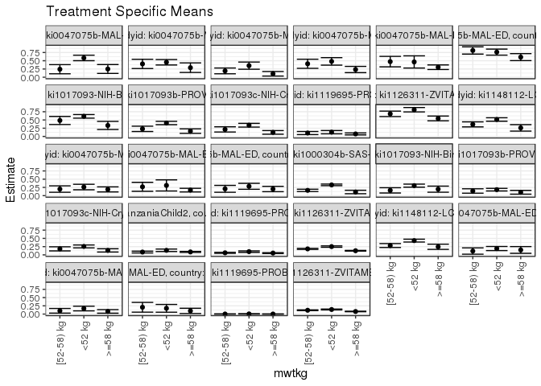

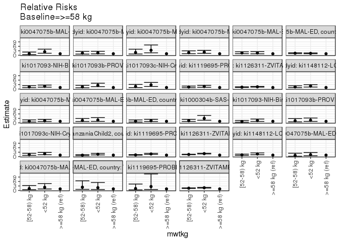

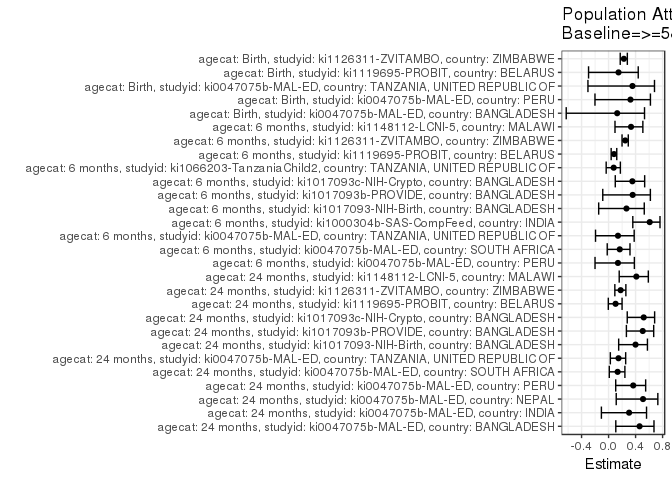

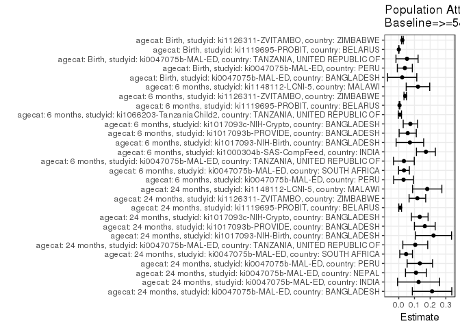

## Results Table

### Parameter: TSM

| agecat | studyid | country | intervention_level | baseline_level | estimate | ci_lower | ci_upper |
| --- | --- | --- | --- | --- | --- | --- | --- |
| Birth | ki0047075b-MAL-ED | BANGLADESH | >=58 kg | NA | 0.1489362 | 0.0469445 | 0.2509279 |
| Birth | ki0047075b-MAL-ED | BANGLADESH | <52 kg | NA | 0.1923077 | 0.1303362 | 0.2542791 |
| Birth | ki0047075b-MAL-ED | BANGLADESH | [52-58) kg | NA | 0.1162791 | 0.0202712 | 0.2122869 |
| Birth | ki0047075b-MAL-ED | PERU | >=58 kg | NA | 0.0808081 | 0.0270246 | 0.1345916 |
| Birth | ki0047075b-MAL-ED | PERU | <52 kg | NA | 0.1682243 | 0.0972188 | 0.2392298 |
| Birth | ki0047075b-MAL-ED | PERU | [52-58) kg | NA | 0.1000000 | 0.0295942 | 0.1704058 |
| Birth | ki0047075b-MAL-ED | TANZANIA, UNITED REPUBLIC OF | >=58 kg | NA | 0.0961538 | 0.0156940 | 0.1766137 |
| Birth | ki0047075b-MAL-ED | TANZANIA, UNITED REPUBLIC OF | <52 kg | NA | 0.1750000 | 0.0567595 | 0.2932405 |
| Birth | ki0047075b-MAL-ED | TANZANIA, UNITED REPUBLIC OF | [52-58) kg | NA | 0.2068966 | 0.0588519 | 0.3549412 |
| Birth | ki1119695-PROBIT | BELARUS | >=58 kg | NA | 0.0020440 | 0.0003496 | 0.0037384 |
| Birth | ki1119695-PROBIT | BELARUS | <52 kg | NA | 0.0053050 | -0.0001768 | 0.0107869 |
| Birth | ki1119695-PROBIT | BELARUS | [52-58) kg | NA | 0.0025402 | 0.0003101 | 0.0047704 |
| Birth | ki1126311-ZVITAMBO | ZIMBABWE | >=58 kg | NA | 0.0782912 | 0.0713385 | 0.0852439 |
| Birth | ki1126311-ZVITAMBO | ZIMBABWE | <52 kg | NA | 0.1391009 | 0.1251328 | 0.1530690 |
| Birth | ki1126311-ZVITAMBO | ZIMBABWE | [52-58) kg | NA | 0.1159821 | 0.1043215 | 0.1276426 |
| 6 months | ki0047075b-MAL-ED | PERU | >=58 kg | NA | 0.1900000 | 0.1129687 | 0.2670313 |
| 6 months | ki0047075b-MAL-ED | PERU | <52 kg | NA | 0.2616822 | 0.1782441 | 0.3451204 |
| 6 months | ki0047075b-MAL-ED | PERU | [52-58) kg | NA | 0.2000000 | 0.1025793 | 0.2974207 |
| 6 months | ki0047075b-MAL-ED | SOUTH AFRICA | >=58 kg | NA | 0.1675978 | 0.1127706 | 0.2224250 |
| 6 months | ki0047075b-MAL-ED | SOUTH AFRICA | <52 kg | NA | 0.3103448 | 0.1416269 | 0.4790627 |
| 6 months | ki0047075b-MAL-ED | SOUTH AFRICA | [52-58) kg | NA | 0.2682927 | 0.1323978 | 0.4041876 |
| 6 months | ki0047075b-MAL-ED | TANZANIA, UNITED REPUBLIC OF | >=58 kg | NA | 0.2021277 | 0.1207801 | 0.2834752 |
| 6 months | ki0047075b-MAL-ED | TANZANIA, UNITED REPUBLIC OF | <52 kg | NA | 0.2842105 | 0.1933281 | 0.3750930 |
| 6 months | ki0047075b-MAL-ED | TANZANIA, UNITED REPUBLIC OF | [52-58) kg | NA | 0.2068966 | 0.1024350 | 0.3113581 |
| 6 months | ki1000304b-SAS-CompFeed | INDIA | >=58 kg | NA | 0.1111111 | 0.0585489 | 0.1636733 |
| 6 months | ki1000304b-SAS-CompFeed | INDIA | <52 kg | NA | 0.3267910 | 0.3021800 | 0.3514019 |
| 6 months | ki1000304b-SAS-CompFeed | INDIA | [52-58) kg | NA | 0.1603774 | 0.1251940 | 0.1955608 |
| 6 months | ki1017093-NIH-Birth | BANGLADESH | >=58 kg | NA | 0.1971831 | 0.1045499 | 0.2898163 |
| 6 months | ki1017093-NIH-Birth | BANGLADESH | <52 kg | NA | 0.3038961 | 0.2579105 | 0.3498817 |
| 6 months | ki1017093-NIH-Birth | BANGLADESH | [52-58) kg | NA | 0.1604938 | 0.0804825 | 0.2405051 |

[output cut: 54 more lines]

### Parameter: E(Y)

| agecat | studyid | country | intervention_level | baseline_level | estimate | ci_lower | ci_upper |
| --- | --- | --- | --- | --- | --- | --- | --- |
| Birth | ki0047075b-MAL-ED | BANGLADESH | NA | NA | 0.1707317 | 0.1236156 | 0.2178478 |
| Birth | ki0047075b-MAL-ED | PERU | NA | NA | 0.1195652 | 0.0812181 | 0.1579123 |
| Birth | ki0047075b-MAL-ED | TANZANIA, UNITED REPUBLIC OF | NA | NA | 0.1487603 | 0.0850915 | 0.2124292 |
| Birth | ki1119695-PROBIT | BELARUS | NA | NA | 0.0023970 | 0.0011029 | 0.0036912 |
| Birth | ki1126311-ZVITAMBO | ZIMBABWE | NA | NA | 0.1012739 | 0.0956332 | 0.1069146 |
| 6 months | ki0047075b-MAL-ED | PERU | NA | NA | 0.2205882 | 0.1712211 | 0.2699554 |
| 6 months | ki0047075b-MAL-ED | SOUTH AFRICA | NA | NA | 0.2008032 | 0.1509453 | 0.2506612 |
| 6 months | ki0047075b-MAL-ED | TANZANIA, UNITED REPUBLIC OF | NA | NA | 0.2348178 | 0.1818480 | 0.2877876 |
| 6 months | ki1000304b-SAS-CompFeed | INDIA | NA | NA | 0.2842105 | 0.2659845 | 0.3024365 |
| 6 months | ki1017093-NIH-Birth | BANGLADESH | NA | NA | 0.2681564 | 0.2306532 | 0.3056597 |
| 6 months | ki1017093b-PROVIDE | BANGLADESH | NA | NA | 0.1597938 | 0.1299995 | 0.1895881 |
| 6 months | ki1017093c-NIH-Crypto | BANGLADESH | NA | NA | 0.2097902 | 0.1799252 | 0.2396552 |
| 6 months | ki1066203-TanzaniaChild2 | TANZANIA, UNITED REPUBLIC OF | NA | NA | 0.0965309 | 0.0835493 | 0.1095126 |
| 6 months | ki1119695-PROBIT | BELARUS | NA | NA | 0.0598408 | 0.0469716 | 0.0727101 |
| 6 months | ki1126311-ZVITAMBO | ZIMBABWE | NA | NA | 0.1668346 | 0.1586345 | 0.1750346 |
| 6 months | ki1148112-LCNI-5 | MALAWI | NA | NA | 0.3679809 | 0.3352903 | 0.4006715 |
| 24 months | ki0047075b-MAL-ED | BANGLADESH | NA | NA | 0.4622642 | 0.3949918 | 0.5295365 |
| 24 months | ki0047075b-MAL-ED | INDIA | NA | NA | 0.4159292 | 0.3515272 | 0.4803312 |
| 24 months | ki0047075b-MAL-ED | NEPAL | NA | NA | 0.2149123 | 0.1614774 | 0.2683472 |
| 24 months | ki0047075b-MAL-ED | PERU | NA | NA | 0.3681592 | 0.3013164 | 0.4350020 |
| 24 months | ki0047075b-MAL-ED | SOUTH AFRICA | NA | NA | 0.3504274 | 0.2891665 | 0.4116882 |
| 24 months | ki0047075b-MAL-ED | TANZANIA, UNITED REPUBLIC OF | NA | NA | 0.7149533 | 0.6543278 | 0.7755787 |
| 24 months | ki1017093-NIH-Birth | BANGLADESH | NA | NA | 0.5547786 | 0.5076945 | 0.6018626 |
| 24 months | ki1017093b-PROVIDE | BANGLADESH | NA | NA | 0.3281250 | 0.2897474 | 0.3665026 |
| 24 months | ki1017093c-NIH-Crypto | BANGLADESH | NA | NA | 0.2568093 | 0.2190047 | 0.2946140 |
| 24 months | ki1119695-PROBIT | BELARUS | NA | NA | 0.0852230 | 0.0552609 | 0.1151851 |
| 24 months | ki1126311-ZVITAMBO | ZIMBABWE | NA | NA | 0.6651376 | 0.6207877 | 0.7094875 |
| 24 months | ki1148112-LCNI-5 | MALAWI | NA | NA | 0.4411765 | 0.4006626 | 0.4816903 |

### Parameter: RR

| agecat | studyid | country | intervention_level | baseline_level | estimate | ci_lower | ci_upper |
| --- | --- | --- | --- | --- | --- | --- | --- |
| Birth | ki0047075b-MAL-ED | BANGLADESH | >=58 kg | >=58 kg | 1.0000000 | 1.0000000 | 1.000000 |
| Birth | ki0047075b-MAL-ED | BANGLADESH | <52 kg | >=58 kg | 1.2912088 | 0.6057693 | 2.752236 |
| Birth | ki0047075b-MAL-ED | BANGLADESH | [52-58) kg | >=58 kg | 0.7807309 | 0.2670760 | 2.282275 |
| Birth | ki0047075b-MAL-ED | PERU | >=58 kg | >=58 kg | 1.0000000 | 1.0000000 | 1.000000 |
| Birth | ki0047075b-MAL-ED | PERU | <52 kg | >=58 kg | 2.0817757 | 0.9465750 | 4.578391 |
| Birth | ki0047075b-MAL-ED | PERU | [52-58) kg | >=58 kg | 1.2375000 | 0.4696521 | 3.260725 |
| Birth | ki0047075b-MAL-ED | TANZANIA, UNITED REPUBLIC OF | >=58 kg | >=58 kg | 1.0000000 | 1.0000000 | 1.000000 |
| Birth | ki0047075b-MAL-ED | TANZANIA, UNITED REPUBLIC OF | <52 kg | >=58 kg | 1.8199999 | 0.6208455 | 5.335304 |
| Birth | ki0047075b-MAL-ED | TANZANIA, UNITED REPUBLIC OF | [52-58) kg | >=58 kg | 2.1517241 | 0.7155263 | 6.470644 |
| Birth | ki1119695-PROBIT | BELARUS | >=58 kg | >=58 kg | 1.0000000 | 1.0000000 | 1.000000 |
| Birth | ki1119695-PROBIT | BELARUS | <52 kg | >=58 kg | 2.5954276 | 0.6078635 | 11.081836 |
| Birth | ki1119695-PROBIT | BELARUS | [52-58) kg | >=58 kg | 1.2427725 | 0.3611349 | 4.276749 |
| Birth | ki1126311-ZVITAMBO | ZIMBABWE | >=58 kg | >=58 kg | 1.0000000 | 1.0000000 | 1.000000 |
| Birth | ki1126311-ZVITAMBO | ZIMBABWE | <52 kg | >=58 kg | 1.7767124 | 1.5538136 | 2.031587 |
| Birth | ki1126311-ZVITAMBO | ZIMBABWE | [52-58) kg | >=58 kg | 1.4814188 | 1.2954492 | 1.694086 |
| 6 months | ki0047075b-MAL-ED | PERU | >=58 kg | >=58 kg | 1.0000000 | 1.0000000 | 1.000000 |
| 6 months | ki0047075b-MAL-ED | PERU | <52 kg | >=58 kg | 1.3772750 | 0.8222730 | 2.306881 |
| 6 months | ki0047075b-MAL-ED | PERU | [52-58) kg | >=58 kg | 1.0526316 | 0.5585235 | 1.983862 |
| 6 months | ki0047075b-MAL-ED | SOUTH AFRICA | >=58 kg | >=58 kg | 1.0000000 | 1.0000000 | 1.000000 |
| 6 months | ki0047075b-MAL-ED | SOUTH AFRICA | <52 kg | >=58 kg | 1.8517241 | 0.9818013 | 3.492440 |
| 6 months | ki0047075b-MAL-ED | SOUTH AFRICA | [52-58) kg | >=58 kg | 1.6008130 | 0.8759360 | 2.925559 |
| 6 months | ki0047075b-MAL-ED | TANZANIA, UNITED REPUBLIC OF | >=58 kg | >=58 kg | 1.0000000 | 1.0000000 | 1.000000 |
| 6 months | ki0047075b-MAL-ED | TANZANIA, UNITED REPUBLIC OF | <52 kg | >=58 kg | 1.4060942 | 0.8409589 | 2.351008 |
| 6 months | ki0047075b-MAL-ED | TANZANIA, UNITED REPUBLIC OF | [52-58) kg | >=58 kg | 1.0235935 | 0.5366802 | 1.952268 |
| 6 months | ki1000304b-SAS-CompFeed | INDIA | >=58 kg | >=58 kg | 1.0000000 | 1.0000000 | 1.000000 |
| 6 months | ki1000304b-SAS-CompFeed | INDIA | <52 kg | >=58 kg | 2.9411187 | 1.7515592 | 4.938560 |
| 6 months | ki1000304b-SAS-CompFeed | INDIA | [52-58) kg | >=58 kg | 1.4433962 | 0.8888559 | 2.343904 |
| 6 months | ki1017093-NIH-Birth | BANGLADESH | >=58 kg | >=58 kg | 1.0000000 | 1.0000000 | 1.000000 |
| 6 months | ki1017093-NIH-Birth | BANGLADESH | <52 kg | >=58 kg | 1.5411874 | 0.9408243 | 2.524657 |
| 6 months | ki1017093-NIH-Birth | BANGLADESH | [52-58) kg | >=58 kg | 0.8139330 | 0.4102941 | 1.614663 |

[output cut: 54 more lines]

### Parameter: PAR

| agecat | studyid | country | intervention_level | baseline_level | estimate | ci_lower | ci_upper |
| --- | --- | --- | --- | --- | --- | --- | --- |
| Birth | ki0047075b-MAL-ED | BANGLADESH | >=58 kg | NA | 0.0217955 | -0.0711957 | 0.1147868 |
| Birth | ki0047075b-MAL-ED | PERU | >=58 kg | NA | 0.0387571 | -0.0090758 | 0.0865901 |
| Birth | ki0047075b-MAL-ED | TANZANIA, UNITED REPUBLIC OF | >=58 kg | NA | 0.0526065 | -0.0178439 | 0.1230569 |
| Birth | ki1119695-PROBIT | BELARUS | >=58 kg | NA | 0.0003530 | -0.0004288 | 0.0011348 |
| Birth | ki1126311-ZVITAMBO | ZIMBABWE | >=58 kg | NA | 0.0229827 | 0.0175324 | 0.0284330 |
| 6 months | ki0047075b-MAL-ED | PERU | >=58 kg | NA | 0.0305882 | -0.0327192 | 0.0938957 |
| 6 months | ki0047075b-MAL-ED | SOUTH AFRICA | >=58 kg | NA | 0.0332054 | -0.0009987 | 0.0674096 |
| 6 months | ki0047075b-MAL-ED | TANZANIA, UNITED REPUBLIC OF | >=58 kg | NA | 0.0326902 | -0.0335404 | 0.0989207 |
| 6 months | ki1000304b-SAS-CompFeed | INDIA | >=58 kg | NA | 0.1730994 | 0.1128340 | 0.2333649 |
| 6 months | ki1017093-NIH-Birth | BANGLADESH | >=58 kg | NA | 0.0709733 | -0.0168808 | 0.1588274 |
| 6 months | ki1017093b-PROVIDE | BANGLADESH | >=58 kg | NA | 0.0569901 | 0.0023540 | 0.1116261 |
| 6 months | ki1017093c-NIH-Crypto | BANGLADESH | >=58 kg | NA | 0.0739206 | 0.0282786 | 0.1195626 |
| 6 months | ki1066203-TanzaniaChild2 | TANZANIA, UNITED REPUBLIC OF | >=58 kg | NA | 0.0072879 | -0.0028769 | 0.0174527 |
| 6 months | ki1119695-PROBIT | BELARUS | >=58 kg | NA | 0.0048213 | 0.0025348 | 0.0071079 |
| 6 months | ki1126311-ZVITAMBO | ZIMBABWE | >=58 kg | NA | 0.0412052 | 0.0333220 | 0.0490885 |
| 6 months | ki1148112-LCNI-5 | MALAWI | >=58 kg | NA | 0.1223668 | 0.0474204 | 0.1973133 |
| 24 months | ki0047075b-MAL-ED | BANGLADESH | >=58 kg | NA | 0.2122642 | 0.0866039 | 0.3379244 |
| 24 months | ki0047075b-MAL-ED | INDIA | >=58 kg | NA | 0.1264555 | -0.0077426 | 0.2606536 |
| 24 months | ki0047075b-MAL-ED | NEPAL | >=58 kg | NA | 0.1096491 | 0.0429474 | 0.1763508 |
| 24 months | ki0047075b-MAL-ED | PERU | >=58 kg | NA | 0.1343930 | 0.0533501 | 0.2154358 |
| 24 months | ki0047075b-MAL-ED | SOUTH AFRICA | >=58 kg | NA | 0.0468559 | 0.0064006 | 0.0873112 |
| 24 months | ki0047075b-MAL-ED | TANZANIA, UNITED REPUBLIC OF | >=58 kg | NA | 0.1051972 | 0.0258737 | 0.1845207 |
| 24 months | ki1017093-NIH-Birth | BANGLADESH | >=58 kg | NA | 0.2214452 | 0.1063831 | 0.3365074 |
| 24 months | ki1017093b-PROVIDE | BANGLADESH | >=58 kg | NA | 0.1659628 | 0.0998747 | 0.2320510 |
| 24 months | ki1017093c-NIH-Crypto | BANGLADESH | >=58 kg | NA | 0.1336209 | 0.0804785 | 0.1867634 |
| 24 months | ki1119695-PROBIT | BELARUS | >=58 kg | NA | 0.0088364 | 0.0000641 | 0.0176088 |
| 24 months | ki1126311-ZVITAMBO | ZIMBABWE | >=58 kg | NA | 0.1186895 | 0.0657357 | 0.1716434 |
| 24 months | ki1148112-LCNI-5 | MALAWI | >=58 kg | NA | 0.1814362 | 0.0882148 | 0.2746576 |

### Parameter: PAF

| agecat | studyid | country | intervention_level | baseline_level | estimate | ci_lower | ci_upper |
| --- | --- | --- | --- | --- | --- | --- | --- |
| Birth | ki0047075b-MAL-ED | BANGLADESH | >=58 kg | NA | 0.1276596 | -0.6273562 | 0.5323840 |
| Birth | ki0047075b-MAL-ED | PERU | >=58 kg | NA | 0.3241506 | -0.2015336 | 0.6198422 |
| Birth | ki0047075b-MAL-ED | TANZANIA, UNITED REPUBLIC OF | >=58 kg | NA | 0.3536325 | -0.3056963 | 0.6800244 |
| Birth | ki1119695-PROBIT | BELARUS | >=58 kg | NA | 0.1472826 | -0.2965904 | 0.4392008 |
| Birth | ki1126311-ZVITAMBO | ZIMBABWE | >=58 kg | NA | 0.2269360 | 0.1725292 | 0.2777655 |
| 6 months | ki0047075b-MAL-ED | PERU | >=58 kg | NA | 0.1386667 | -0.2007227 | 0.3821262 |
| 6 months | ki0047075b-MAL-ED | SOUTH AFRICA | >=58 kg | NA | 0.1653631 | -0.0200531 | 0.3170760 |
| 6 months | ki0047075b-MAL-ED | TANZANIA, UNITED REPUBLIC OF | >=58 kg | NA | 0.1392150 | -0.1933887 | 0.3791203 |
| 6 months | ki1000304b-SAS-CompFeed | INDIA | >=58 kg | NA | 0.6090535 | 0.3587329 | 0.7616607 |
| 6 months | ki1017093-NIH-Birth | BANGLADESH | >=58 kg | NA | 0.2646714 | -0.1465927 | 0.5284217 |
| 6 months | ki1017093b-PROVIDE | BANGLADESH | >=58 kg | NA | 0.3566476 | -0.0862704 | 0.6189693 |
| 6 months | ki1017093c-NIH-Crypto | BANGLADESH | >=58 kg | NA | 0.3523551 | 0.0991330 | 0.5343997 |
| 6 months | ki1066203-TanzaniaChild2 | TANZANIA, UNITED REPUBLIC OF | >=58 kg | NA | 0.0754980 | -0.0355930 | 0.1746720 |
| 6 months | ki1119695-PROBIT | BELARUS | >=58 kg | NA | 0.0805692 | 0.0382642 | 0.1210134 |
| 6 months | ki1126311-ZVITAMBO | ZIMBABWE | >=58 kg | NA | 0.2469824 | 0.1993890 | 0.2917467 |
| 6 months | ki1148112-LCNI-5 | MALAWI | >=58 kg | NA | 0.3325359 | 0.0950235 | 0.5077128 |
| 24 months | ki0047075b-MAL-ED | BANGLADESH | >=58 kg | NA | 0.4591837 | 0.1069398 | 0.6724943 |
| 24 months | ki0047075b-MAL-ED | INDIA | >=58 kg | NA | 0.3040314 | -0.1063867 | 0.5622034 |
| 24 months | ki0047075b-MAL-ED | NEPAL | >=58 kg | NA | 0.5102041 | 0.1131669 | 0.7294868 |
| 24 months | ki0047075b-MAL-ED | PERU | >=58 kg | NA | 0.3650404 | 0.1056168 | 0.5492159 |
| 24 months | ki0047075b-MAL-ED | SOUTH AFRICA | >=58 kg | NA | 0.1337108 | 0.0103960 | 0.2416593 |
| 24 months | ki0047075b-MAL-ED | TANZANIA, UNITED REPUBLIC OF | >=58 kg | NA | 0.1471385 | 0.0260530 | 0.2531702 |
| 24 months | ki1017093-NIH-Birth | BANGLADESH | >=58 kg | NA | 0.3991597 | 0.1495221 | 0.5755220 |
| 24 months | ki1017093b-PROVIDE | BANGLADESH | >=58 kg | NA | 0.5057915 | 0.2639459 | 0.6681738 |
| 24 months | ki1017093c-NIH-Crypto | BANGLADESH | >=58 kg | NA | 0.5203118 | 0.2763564 | 0.6820248 |
| 24 months | ki1119695-PROBIT | BELARUS | >=58 kg | NA | 0.1036861 | -0.0040036 | 0.1998249 |
| 24 months | ki1126311-ZVITAMBO | ZIMBABWE | >=58 kg | NA | 0.1784436 | 0.0926522 | 0.2561232 |
| 24 months | ki1148112-LCNI-5 | MALAWI | >=58 kg | NA | 0.4112554 | 0.1574010 | 0.5886297 |